[figure not shown]

# PhyloCactus 🌵

**Molecular identification report**

Sample SRR26398994 · run SRR26398994

| item | value |
| --- | --- |
| Identification run | 2026-10-15 08:07:55 -03 on machine not recorded |
| Data | Genome skimming or whole-genome sequencing reads (Illumina, paired-end); plastome and nrDNA assembled with GetOrganelle |
| Loci found | ITS, atpB-rbcL, matK, ndhF-rpl32, psbA-trnH, psbE-petL, psbJ-petA, rbcL, rpL16, rpl32-trnL, trnQ-rps16 (detected by overlap with the library; no locus was declared, so every locus of the library was t… |
| Identical to the library | matK identical to library accession JF786773.1; JF786860.1; JF786863.1; OK206456.1; OK206457.1; OK206458.1; OK206461.1; OL420672.1; OL420673.1; OL420674.1; ndhF-rpl32 identical to library accession JF… |
| Library | Sanger records of GenBank (phylotaR) |
| Answers | 11 loci found: 0 named to species (state 1), 1 to genus (state 2), 10 not assignable (state 3); not found: pepC_like, phyC, trnL-trnF, trnS-trnG |
| Reading | Each locus is answered on its own; no call is made across loci (section 3) |

## 1. Query and route

| item | value |
| --- | --- |
| Query | SRR26398994 |
| Input | examples/SRR26398994_1.fastq.gz; examples/SRR26398994_2.fastq.gz |
| Input type | Genome skimming or whole-genome sequencing reads (Illumina, paired-end); plastome and nrDNA assembled with GetOrganelle |
| md5 of the input | c20cdd6df142b39fa10fb8f28cd4413d; 79b2cdf7593a5b533ab9aacef3d50b55 |
| Run | SRR26398994 |

Steps of the route: fastp; GetOrganelle embplant_pt; GetOrganelle embplant_nr; crop; cut to locus core; IdTaxa; cut to genus core; longest region per locus. Steps in light grey were not needed for this query.

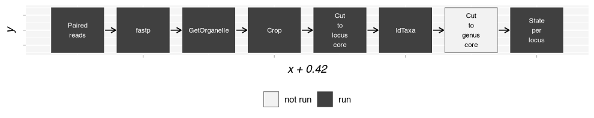

## 2. Answer per locus

One answer per locus, each from its own model; state 1 names a species, state 2 a genus, state 3 is not assignable. The dashed line is the threshold of 60. A species is named only when its confidence also reaches the species threshold of its locus (column species_threshold, set in step 9 from the queries of the validation whose species was absent from the library); under it the locus is named at genus rank, with reason below_species_threshold, and the species IdTaxa reached is listed in section 4.

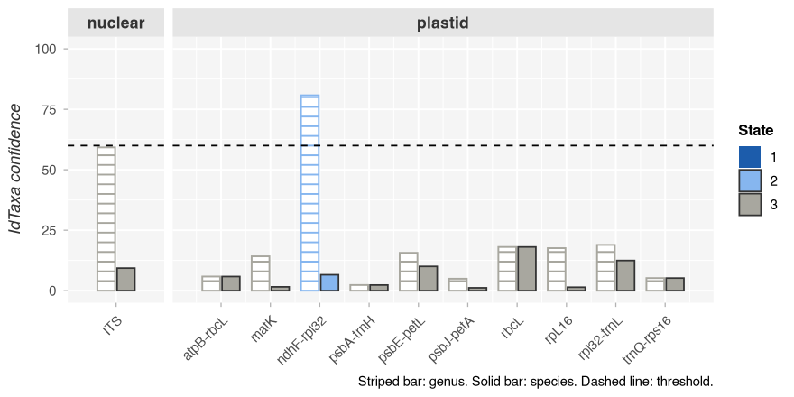

| query | locus | compartment | state | predicted_species | predicted_genus | genus_confidence | species_confidence | species_threshold | reason | region_length | validation_ws_rate_species_present | validation_ws_rate_species_absent | identical_to_library | contig | organelle |
| --- | --- | --- | --- | --- | --- | --- | --- | --- | --- | --- | --- | --- | --- | --- | --- |
| nrdna_1 | ITS | nuclear | 3 |  |  | 59.258 | 9.331 | 60.920 | low_confidence | 567 | 0.019 | 0.056 | JF787016.1 | nrdna_1 | nrdna |
| plastome_12 | atpB-rbcL | plastid | 3 |  |  | 5.855 | 5.855 | 69.405 | low_confidence | 193 | 0.021 | 0.080 |  | plastome_12 | plastome |
| plastome_11 | matK | plastid | 3 |  |  | 14.216 | 1.586 | 66.884 | low_confidence | 3354 | 0.025 | 0.068 | JF786773.1; JF786860.1; JF786863.1; OK206456.1; OK206457.1; OK206458.1; OK206461.1; OL420672.1; OL420673.1; OL420674.1 | plastome_11 | plastome |
| plastome_10 | ndhF-rpl32 | plastid | 2 |  | Opuntia | 80.786 | 6.583 | 71.360 |  | 263 | 0.022 | 0.094 | JF787309.1; JF787312.1; JF787313.1; JF787315.1; JF787316.1; JF787318.1; JF787319.1; JF787322.1; JF787324.1; JF787327.1; JF787328.1; JF787330.1; JF787349.1; JF787354.1; JF787356.1; JF787357.1; JF787360… | plastome_10 | plastome |
| plastome_11 | psbA-trnH | plastid | 3 |  |  | 2.342 | 2.342 | 68.854 | low_confidence | 391 | 0.045 | 0.091 |  | plastome_11 | plastome |
| plastome_16 | psbE-petL | plastid | 3 |  |  | 15.660 | 10.040 | 72.911 | low_confidence | 225 | 0.028 | 0.104 |  | plastome_16 | plastome |
| plastome_16 | psbJ-petA | plastid | 3 |  |  | 4.946 | 1.186 | 67.961 | low_confidence | 549 | 0.014 | 0.065 |  | plastome_16 | plastome |
| plastome_12 | rbcL | plastid | 3 |  |  | 18.077 | 18.077 | 60.000 | low_confidence | 545 | 0.029 | 0.033 | HO058905.1; KF724213.1; MT304108.1; OP711358.1 | plastome_12 | plastome |
| plastome_13 | rpL16 | plastid | 3 |  |  | 17.588 | 1.436 | 70.354 | low_confidence | 1107 | 0.031 | 0.107 |  | plastome_13 | plastome |
| plastome_10 | rpl32-trnL | plastid | 3 |  |  | 18.932 | 12.479 | 84.317 | low_confidence | 223 | 0.021 | 0.309 |  | plastome_10 | plastome |
| plastome_9 | trnQ-rps16 | plastid | 3 |  |  | 5.213 | 5.213 | 71.360 | low_confidence | 603 | 0.000 | 0.089 |  | plastome_9 | plastome |

Loci not found in the sample: pepC_like, phyC, trnL-trnF, trnS-trnG.

## 3. Reading across loci

The loci are read side by side; no call is made across them. For each genus and species named by any locus, at any confidence: the loci that name it and how many of them assign it at the threshold. Loci with no answer are listed under rank *none*.

| rank | taxon | n_loci | n_assigned | loci | max_confidence |
| --- | --- | --- | --- | --- | --- |
| genus | Browningia | 1 | 0 | trnQ-rps16 | 5.213 |
| genus | Echinocereus | 1 | 0 | psbA-trnH | 2.342 |
| genus | Hatiora | 1 | 0 | rpl32-trnL | 18.932 |
| genus | Lophocereus | 1 | 0 | psbE-petL | 15.660 |
| genus | Micropuntia | 1 | 0 | atpB-rbcL | 5.855 |
| genus | Opuntia | 5 | 1 | ITS; matK; ndhF-rpl32; psbJ-petA; rpL16 | 80.786 |
| genus | Tacinga | 1 | 0 | rbcL | 18.077 |
| species | Browningia_hertlingiana | 1 | 0 | trnQ-rps16 | 5.213 |
| species | Echinocereus_rayonesensis | 1 | 0 | psbA-trnH | 2.342 |
| species | Hatiora_cylindrica | 1 | 0 | rpl32-trnL | 12.479 |
| species | Lophocereus_marginatus | 1 | 0 | psbE-petL | 10.040 |
| species | Micropuntia_pulchella | 1 | 0 | atpB-rbcL | 5.855 |
| species | Opuntia_cymochila | 1 | 0 | ndhF-rpl32 | 6.583 |
| species | Opuntia_macbridei | 1 | 0 | rpL16 | 1.436 |
| species | Opuntia_pycnantha | 1 | 0 | psbJ-petA | 1.186 |
| species | Opuntia_stenopetala | 1 | 0 | matK | 1.586 |
| species | Opuntia_tapona | 1 | 0 | ITS | 9.331 |
| species | Tacinga_werneri | 1 | 0 | rbcL | 18.077 |
| none |  | 4 | 0 | pepC_like; phyC; trnL-trnF; trnS-trnG |  |

## 4. Alternatives (not assigned)

Alternatives under the threshold of 60 (for a species, under the species threshold of its locus), not assigned. IdTaxa gives one path per query and locus: the alternatives are that path when it falls under the threshold, and in state 2 the species of the named genus in the library. They are not identifications; they say where the data point when they do not decide.

Best path under the threshold, per locus:

| query | locus | genus | species | genus_confidence | species_confidence | species_threshold |
| --- | --- | --- | --- | --- | --- | --- |
| nrdna_1 | ITS | Opuntia | Opuntia_tapona | 59.258 | 9.331 | 60.920 |
| plastome_12 | atpB-rbcL | Micropuntia | Micropuntia_pulchella | 5.855 | 5.855 | 69.405 |
| plastome_11 | matK | Opuntia | Opuntia_stenopetala | 14.216 | 1.586 | 66.884 |
| plastome_10 | ndhF-rpl32 | Opuntia | Opuntia_cymochila | 80.786 | 6.583 | 71.360 |
| plastome_11 | psbA-trnH | Echinocereus | Echinocereus_rayonesensis | 2.342 | 2.342 | 68.854 |
| plastome_16 | psbE-petL | Lophocereus | Lophocereus_marginatus | 15.660 | 10.040 | 72.911 |
| plastome_16 | psbJ-petA | Opuntia | Opuntia_pycnantha | 4.946 | 1.186 | 67.961 |
| plastome_12 | rbcL | Tacinga | Tacinga_werneri | 18.077 | 18.077 | 60.000 |
| plastome_13 | rpL16 | Opuntia | Opuntia_macbridei | 17.588 | 1.436 | 70.354 |
| plastome_10 | rpl32-trnL | Hatiora | Hatiora_cylindrica | 18.932 | 12.479 | 84.317 |
| plastome_9 | trnQ-rps16 | Browningia | Browningia_hertlingiana | 5.213 | 5.213 | 71.360 |

Species of the named genus in the library, for the loci in state 2 (all of them in `REPORT_SRR26398994_alternatives.csv`):

| locus | genus | species_in_library | species |
| --- | --- | --- | --- |
| ndhF-rpl32 | Opuntia | 71 | Opuntia_abjecta, Opuntia_aurea, Opuntia_austrina, Opuntia_basilaris, Opuntia_boldinghii, Opuntia_bravoana, Opuntia_camanchica, Opuntia_cespitosa, Opuntia_chaffeyi, Opuntia_chisosensis, Opuntia_cocheni… |

## 5. How far to trust each locus

Wrong-species rate of each locus in the validation folds: with the species of the query in the library (scheme E) and without it (scheme G).

| locus | validation_ws_rate_species_present | validation_ws_rate_species_absent |
| --- | --- | --- |
| atpB-rbcL | 0.021 | 0.080 |
| matK | 0.025 | 0.068 |
| ndhF-rpl32 | 0.022 | 0.094 |
| psbA-trnH | 0.045 | 0.091 |
| psbE-petL | 0.028 | 0.104 |
| psbJ-petA | 0.014 | 0.065 |
| rbcL | 0.029 | 0.033 |
| rpL16 | 0.031 | 0.107 |
| rpl32-trnL | 0.021 | 0.309 |
| trnL-trnF | 0.008 | 0.068 |
| trnQ-rps16 | 0.000 | 0.089 |
| trnS-trnG | 0.040 | 0.325 |
| ITS | 0.019 | 0.056 |
| pepC_like | 0.019 | 0.116 |
| phyC | 0.020 | 0.089 |

Per-genus discrimination not available: run summarise_barcoding_genus_discrimination().

## 6. Sampling of the named genera in the library

Sequences per species and locus in the library for the genera named by the query; empty cells are species with no sequence of that locus; species named by the query in bold.

[figure not shown]

## 7. Reads

| kind | name | value |
| --- | --- | --- |
| output | fastp.json | 2e02dcdb981a018a30952081ae2186a6 |
| output | plastome_path.fasta | 39fc7b6fa0d8f1157e3211923351831a |
| output | nrdna_path.fasta | de04984d9d2ad3094c4ce99ee6f69042 |
| tool | fastp | fastp 1.3.7 |
| tool | get_organelle_from_reads.py | GetOrganelle v1.7.7.1 |
| command | 1 | fastp -i examples/SRR26398994_1.fastq.gz -I examples/SRR26398994_2.fastq.gz -o 11_barcoding/10_identify/SRR26398994/clean_1.fq.gz -O 11_barcoding/10_identify/SRR26398994/clean_2.fq.gz -w 4 -j 11_barco… |
| command | 2 | get_organelle_from_reads.py -1 11_barcoding/10_identify/SRR26398994/clean_1.fq.gz -2 11_barcoding/10_identify/SRR26398994/clean_2.fq.gz -F embplant_pt -o 11_barcoding/10_identify/SRR26398994/getorgane… |
| command | 3 | get_organelle_from_reads.py -1 11_barcoding/10_identify/SRR26398994/clean_1.fq.gz -2 11_barcoding/10_identify/SRR26398994/clean_2.fq.gz -F embplant_nr -o 11_barcoding/10_identify/SRR26398994/getorgane… |

## 8. Library, models and software

Names follow the Cactaceae checklist of Korotkova et al. (2021, Willdenowia 51(2): 251-270). Sources of the library: phylotaR clusters of GenBank records and, where present, loci cut from GenBank plastomes.

| locus | species | sequences | from_phylotaR | from_genbank_plastomes |
| --- | --- | --- | --- | --- |
| ITS | 330 | 685 | 685 | 0 |
| atpB-rbcL | 225 | 326 | 326 | 0 |
| matK | 856 | 1446 | 1446 | 0 |
| ndhF-rpl32 | 83 | 109 | 109 | 0 |
| pepC_like | 133 | 163 | 163 | 0 |
| phyC | 169 | 400 | 400 | 0 |
| psbA-trnH | 560 | 801 | 801 | 0 |
| psbE-petL | 144 | 213 | 213 | 0 |
| psbJ-petA | 91 | 202 | 202 | 0 |
| rbcL | 295 | 358 | 358 | 0 |
| rpL16 | 723 | 990 | 990 | 0 |
| rpl32-trnL | 170 | 363 | 363 | 0 |
| trnL-trnF | 664 | 1072 | 1072 | 0 |
| trnQ-rps16 | 151 | 178 | 178 | 0 |
| trnS-trnG | 187 | 301 | 301 | 0 |

| kind | name | value |
| --- | --- | --- |
| setting | run_name | SRR26398994 |
| setting | threshold | 60 |
| setting | seed | 1 |
| setting | min_overlap | 100 |
| setting | loci_declared | none |
| setting | date | 2026-10-15 08:07:55 -03 |
| software | R | R version 4.6.1 (2026-06-24) |
| software | PhyloCactus | 0.4.5.9000 |
| software | DECIPHER | 3.8.1 |
| software | Biostrings | 2.80.2 |
| library | LIB_ITS.fasta | 7c795df020c3a13b6105c81a0bb08296 |
| library | LIB_atpB-rbcL.fasta | 83975d589b4b31bb222ac37108a4822f |
| library | LIB_matK.fasta | 192edba08d61fc1953634c48915fc6d5 |
| library | LIB_ndhF-rpl32.fasta | bc9ebd4101b43941a6dca170bd8613d5 |
| library | LIB_pepC_like.fasta | 8e08dea3ecc796b83acf623a23315949 |
| library | LIB_phyC.fasta | c5e3c650220bae547b4c49a09d389744 |
| library | LIB_psbA-trnH.fasta | f6e88a1a663e9fcf5adc04da2a7b5c66 |
| library | LIB_psbE-petL.fasta | 11e7e8d443a04677146463b6598beb2a |
| library | LIB_psbJ-petA.fasta | 1ab3b0ba0dcc547d9cb5732414d07d9a |
| library | LIB_rbcL.fasta | 2954ea647d6828b33e577be25ba507f4 |
| library | LIB_rpL16.fasta | d4ea77324108c50155486b36d076d7a8 |
| library | LIB_rpl32-trnL.fasta | 6137386cd6eb9bc05c45baa5404d96ac |
| library | LIB_trnL-trnF.fasta | 649cb4dc8f6ff5d7cb116515116d1e9d |
| library | LIB_trnQ-rps16.fasta | 5483a02dbecc6b389d1ed69911ee9f66 |
| library | LIB_trnS-trnG.fasta | a4cc203040c4a6d2d34af96e68fb1e00 |
| library | UNMASKED_ITS.fasta | 0afe78cba8efe4e6492b086a94195a6a |
| library | UNMASKED_atpB-rbcL.fasta | d9fe05bf2819eddc926ba4d72294db5b |
| library | UNMASKED_matK.fasta | 074dac4f8314621b0d19d22853d9c8c5 |
| library | UNMASKED_ndhF-rpl32.fasta | 4546cbe630779f31031055e38b96e075 |
| library | UNMASKED_pepC_like.fasta | 2ccbcaec6eb489c88dc32e9c48f9119f |
| library | UNMASKED_phyC.fasta | 8abafd40344029a34db59a9cfa2fb5bf |
| library | UNMASKED_psbA-trnH.fasta | 2f894e03e37089c2e37872092dc64242 |
| library | UNMASKED_psbE-petL.fasta | 0860f8e185e0e30fbe423e1098fc00ff |
| library | UNMASKED_psbJ-petA.fasta | 3df72cf7817e97310316ec7897aef2bb |
| library | UNMASKED_rbcL.fasta | 3f1fc99d167deda5bfc154b6f57483b2 |
| library | UNMASKED_rpL16.fasta | 2d086dac200f007a2f500b3b2d42d5a5 |
| library | UNMASKED_rpl32-trnL.fasta | fa94aeeabfe1b6aeabe197f98febd9ab |
| library | UNMASKED_trnL-trnF.fasta | a8d3fd6c72d238111ddb85e019e6e828 |
| library | UNMASKED_trnQ-rps16.fasta | 3a95179b8ef73948a4402af55ba2a1f2 |
| library | UNMASKED_trnS-trnG.fasta | ce3f19ddad306646296e3bab69af4f13 |
| model | MODEL_idtaxa_ITS.rds | 26de040996838cc369d6fe56c23760cc |
| model | MODEL_idtaxa_atpB-rbcL.rds | f3892d195ff4275682ea3d44288ab4d8 |
| model | MODEL_idtaxa_matK.rds | 09d449ef17b25fa525b4ec7e44ddc9b2 |
| model | MODEL_idtaxa_ndhF-rpl32.rds | 4a643c9b28fe4bfb32a515deb34db5e0 |
| model | MODEL_idtaxa_pepC_like.rds | ca78c63a4c82d83bee2ffc1c87490dfc |
| model | MODEL_idtaxa_phyC.rds | 547bacb1d98f732b1466e54b8268d248 |
| model | MODEL_idtaxa_psbA-trnH.rds | 38367f561df54cc9c1d63a3d8c487d80 |
| model | MODEL_idtaxa_psbE-petL.rds | bb8b6d4ab16d081e34d8a06476f5f9b5 |
| model | MODEL_idtaxa_psbJ-petA.rds | 58059987f94f6431b24d3594806b80d9 |
| model | MODEL_idtaxa_rbcL.rds | 4322494c8ab35f9f6e8345d40e0387b3 |
| model | MODEL_idtaxa_rpL16.rds | 6409ac9dc13765087887e6f032434b12 |
| model | MODEL_idtaxa_rpl32-trnL.rds | cbce3ee038f679c1d4fa04ce8faaf048 |
| model | MODEL_idtaxa_trnL-trnF.rds | 16795c3bb08cf4b82ba1acd7a3093d30 |
| model | MODEL_idtaxa_trnQ-rps16.rds | 5db37c6252f10537e6ed83204b34bf9e |
| model | MODEL_idtaxa_trnS-trnG.rds | 35f9787c728b15b81bccf976e5e51d99 |

## 9. Limits

Standard plant barcodes resolve about half of the species, complete plastomes a little more, and a part of species is not resolvable by any of them, because of hybridisation, incomplete lineage sorting and species that are evolutionary grades rather than clades (Zeng et al., 2026, New Phytologist). In Cactaceae the plastid loci vary little within genera and many species have one sequence or none in the library (section 6). A state 3 is not evidence that the species is absent from the library; a state 1 relies on the species being in it. If the query comes from a specimen already in the library, its answer is not an independent test.